# $K$NN

Author

Kendall Leonard

Published

February 10, 2025

**Abstract:**

This is a technical blog post of **both** an HTML file *and* [.qmd file](https://raw.githubusercontent.com/cd-public/D505/refs/heads/master/hws/src/knn.qmd) hosted on GitHub pages.

# 1. Setup

```r
library(tidyverse)
library(fastDummies)
library(caret)
wine <- readRDS(gzcon(url("https://github.com/cd-public/D505/raw/master/dat/pinot.rds")))
```

## 2. $K$NN Concepts

> TODO: *Explain how the choice of K affects the quality of your prediction when using a* $K$ Nearest Neighbors algorithm.

> **ANSWER**: The choice of K, meaning how many neighbors are we comparing to to determine the identity of the data point in question, can HEAVILY affect the quality of our prediction when using a KNN model. Extreme K values can lead to under-fitting or over-fitting, meaning our model will perform poorly on any new data we enter in. Over fitting occurs when we pick a K that is too small, and means that our algorithm is sensitive to noise, and the choices it makes might not be representative of the entire dataset. Under fitting, which happens when we have too large of a K value, tends to lose any local trends and follows the global trends.

## 3. Feature Engineering

1. Create a version of the year column that is a *factor* (instead of numeric).

```r
wine<-wine%>%
  mutate(year= as.factor(year))
```

1. Create dummy variables that indicate the presence of “cherry”, “chocolate” and “earth” in the description.
   - Take care to handle upper and lower case characters.

```r
processed_wine <- wine %>%
  mutate(description_nospecial = gsub("[[:punct:]]", "", description)) %>%
  mutate(description_nospecial = tolower(description_nospecial)) %>%
  mutate(
    chocolate_flag = ifelse(grepl("chocolate", description_nospecial), 1, 0),
    earth_flag = ifelse(grepl("earth", description_nospecial), 1, 0),
    cherry_flag = ifelse(grepl("cherry", description_nospecial), 1, 0)
  )
```

3. Create 3 new features that represent the interaction between time and the cherry, chocolate and earth indicators.

```r
keywords <- c("chocolate", "cherry", "earth")
for (keyword in keywords) {
  processed_wine <- processed_wine %>%
    mutate(!!sym(keyword) := str_detect(description_nospecial, keyword))
}
# Convert the 'year' column to numeric, if it's currently a factor
processed_wine <- processed_wine %>%
  mutate(year = as.numeric(as.character(year)))

# Create a flag for year before 2003
processed_wine <- processed_wine %>%
  mutate(year_before_2003 = ifelse(year < 2003, 1, 0))

# Create interaction features between year_before_2003 and each keyword flag
for (keyword in keywords) {
  processed_wine <- processed_wine %>%
    mutate(!!paste0("interaction_", keyword) := year_before_2003 * !!sym(keyword))
}
processed_wine<-processed_wine%>%
  mutate(year= as.factor(year))
```

4. Remove the description column from the data.

```r
processed_wine<-processed_wine%>%
  select(-c(description, description_nospecial))
```

## 4. Preprocessing

1. Preprocess the dataframe from the previous code block using BoxCox, centering and scaling of the numeric features

```r
preprocessed_wine<-processed_wine %>%
  preProcess(method = c("BoxCox","center","scale"))
```

2. Create dummy variables for the `year` factor column

```r
wine_with_dummies <- processed_wine %>%
  mutate(year_dummies = model.matrix(~ year - 1))

preprocessed_wine_w_dummies<-wine_with_dummies %>%
  preProcess(method = c("BoxCox","center","scale"))%>%
  predict(wine_with_dummies)
```

## 5. Running $K$NN

1. Split the dataframe into an 80/20 training and test set

```r
set.seed(505)
wine_index <- createDataPartition(preprocessed_wine_w_dummies$province, p = 0.8, list = FALSE)
train <- preprocessed_wine_w_dummies[ wine_index, ]
test <- preprocessed_wine_w_dummies[-wine_index, ]
```

```r
# Set up 5-fold cross-validation
train_control <- trainControl(method = "cv", number = 5, search = "grid")

# Define the tuning grid for kknn
k_values <- expand.grid(kmax = 3:15,    # kmax represents the number of neighbors
                        distance = 2,   # Use Euclidean distance (you can experiment with other values like 1 for Manhattan)
                        kernel = "rectangular")  # You can also try other kernels like "gaussian", "epanechnikov"

# Train the KNN model using kknn for better tie handling
knn_model <- train(province ~ year_before_2003 + chocolate + cherry + earth +
                       interaction_chocolate + interaction_cherry + interaction_earth,
                   data = train,
                   method = "kknn",  # Use kknn for better handling of ties
                   trControl = train_control,
                   tuneGrid = k_values)

# View the results
print(knn_model)
```

```
k-Nearest Neighbors

6707 samples
   7 predictor
   6 classes: 'Burgundy', 'California', 'Casablanca_Valley', 'Marlborough', 'New_York', 'Oregon'

No pre-processing
Resampling: Cross-Validated (5 fold)
Summary of sample sizes: 5365, 5367, 5365, 5366, 5365
Resampling results across tuning parameters:

  kmax  Accuracy   Kappa
   3    0.4226902  0.025039553
   4    0.4030163  0.003468113
   5    0.4368499  0.027695659
   6    0.4098717  0.027558374
   7    0.4062874  0.036827268
   8    0.4110653  0.035954847
   9    0.4021136  0.025429968
  10    0.4143533  0.057866351
  11    0.4326842  0.036506097
  12    0.4278974  0.055448909
  13    0.4143533  0.057866351
  14    0.4240404  0.064123443
  15    0.4326842  0.036506097

Tuning parameter 'distance' was held constant at a value of 2
Tuning
 parameter 'kernel' was held constant at a value of rectangular
Accuracy was used to select the optimal model using the largest value.
The final values used for the model were kmax = 5, distance = 2 and kernel
 = rectangular.
```

```r
# Make predictions
predictions <- predict(knn_model, newdata = test)
```

3. Display the confusion matrix on the test data

```r
# Ensure 'province' in test_data is a factor with appropriate levels
test$provinces <- factor(test$province)

# Convert predictions to a factor with the same levels as test$province
predictions <- factor(predictions, levels = levels(test$provinces))

# Now you can use confusionMatrix
cm<-confusionMatrix(predictions, test$provinces)
cm
```

```
Confusion Matrix and Statistics

                   Reference
Prediction          Burgundy California Casablanca_Valley Marlborough New_York
  Burgundy                 0          0                 0           0        0
  California               0          3                 0           0        0
  Casablanca_Valley        0          0                 0           0        0
  Marlborough              1         11                 1           0        1
  New_York                 0          0                 0           0        0
  Oregon                 237        777                25          45       25
                   Reference
Prediction          Oregon
  Burgundy               1
  California             4
  Casablanca_Valley      0
  Marlborough           32
  New_York               0
  Oregon               510

Overall Statistics

               Accuracy : 0.3066
                 95% CI : (0.2846, 0.3294)
    No Information Rate : 0.4728
    P-Value [Acc > NIR] : 1

                  Kappa : -0.0185

 Mcnemar's Test P-Value : NA

Statistics by Class:

                     Class: Burgundy Class: California Class: Casablanca_Valley
Sensitivity                0.0000000          0.003793                  0.00000
Specificity                0.9993031          0.995465                  1.00000
Pos Pred Value             0.0000000          0.428571                      NaN
Neg Pred Value             0.8576555          0.527011                  0.98446
Prevalence                 0.1422594          0.472803                  0.01554
Detection Rate             0.0000000          0.001793                  0.00000
Detection Prevalence       0.0005977          0.004184                  0.00000
Balanced Accuracy          0.4996516          0.499629                  0.50000
                     Class: Marlborough Class: New_York Class: Oregon
Sensitivity                      0.0000         0.00000        0.9324
Specificity                      0.9717         1.00000        0.0151
Pos Pred Value                   0.0000             NaN        0.3150
Neg Pred Value                   0.9723         0.98446        0.3148
Prevalence                       0.0269         0.01554        0.3270
Detection Rate                   0.0000         0.00000        0.3048
Detection Prevalence             0.0275         0.00000        0.9677
Balanced Accuracy                0.4859         0.50000        0.4737
```

## 6. Kappa

How do we determine whether a Kappa value is represents a good or bad outcome?

> Answer: *(I did an awful lot of reseach on this, so enjoy the info dump). Cohen’s kappa is a measurement of the extent to which data collectors (raters) assign the same score to the same variable is called interrater reliability. Cohen’s kappa takes into account “chance agreement” between raters, the possibility that raters actually guess on at least some variables due to uncertainty.(1) When it comes to interpreting the Kappa value, there are a lot of conflicting ideas on what counts as “good”. Cohen suggested the Kappa result be interpreted as follows: values ≤ 0 as indicating no agreement and 0.01–0.20 as none to slight, 0.21–0.40 as fair, 0.41– 0.60 as moderate, 0.61–0.80 as substantial, and 0.81–1.00 as almost perfect agreement. But just because the rater’s are in agreement, doesn’t necessarily mean that the outcome is “good” or “bad”, as that is heavily dependent on context. In this case, with a negative kappa value, we can say that our model is quite bad at predicting wines based on providence. So in our case, while its bad that this model didn’t work, its good to know that it needs improvement!*

## 7. Improvement

For the sake of easier interpretation, I created this visual:

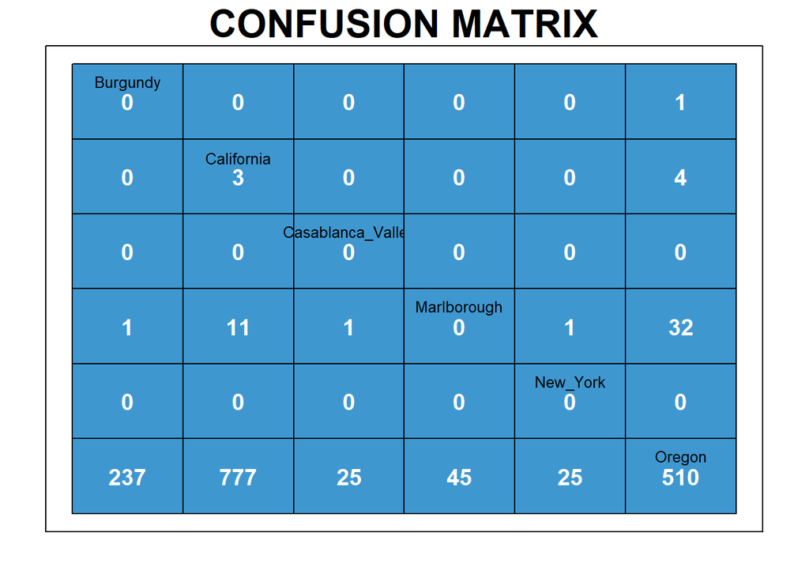

```r
draw_confusion_matrix(cm)
```

How can we interpret the confusion matrix, and how can we improve in our predictions?

## Citations

McHugh, Mary L. “Interrater reliability: the kappa statistic.” Biochemia medica vol. 22,3 (2012): 276-82.